# PP model comparisons

This is a comparison of average daily PP using model BIOv2 and input data of different composite length (monthly, 8day, and daily). The output is total daily primary production (mg C / m<sup>2</sup> / day), averaged over the month or 8day period for monthly/8day input composites. All of these models use VIIRS-SNPP and a uniform biomass profile in the water column. The PI parameters were calculated by taking the median of the parameters from the BIOv1 input file for this date and the NWA region (i.e. using a single alphab and pmb for the entire region).

The percent difference between composites are mapped, with a table of Pearson’s correlation coefficients between percent difference and three variables: chla, latitude, bathymetry. Note that the density plot x-axis range is the mean +- 2stdev.

`% difference = (100 * (x - y) / y)`  
x = short composite  
y = longer composite

## Results

### 201210

#### Monthly average daily PP

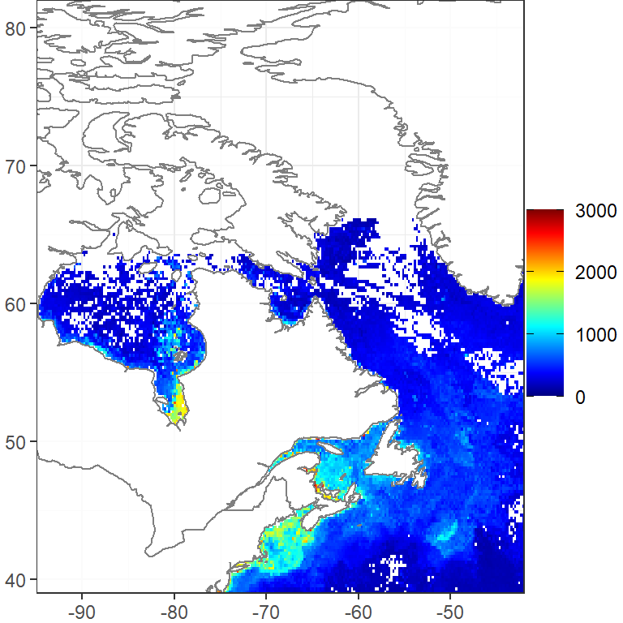

##### 8day average daily PP, and % difference from monthly average

Note that the %error - chla correlation coefficient here was calculated using the monthly chla.

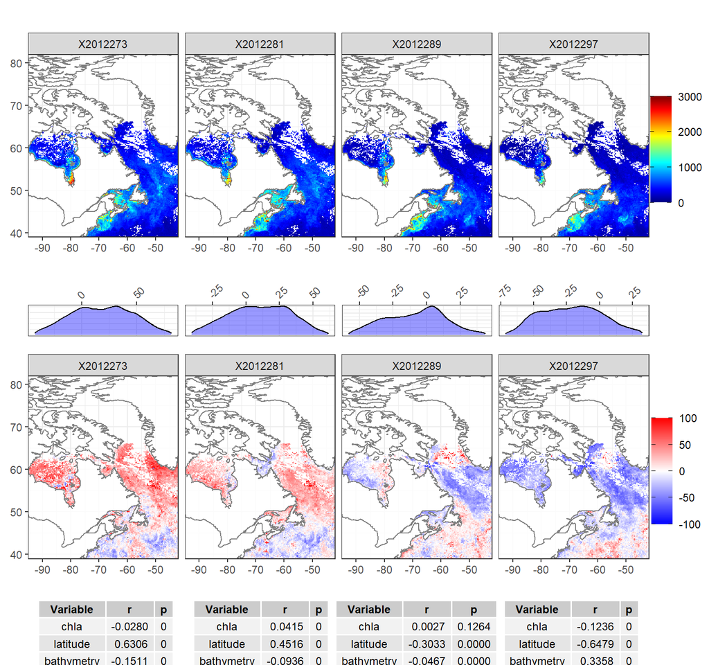

#### 8day average daily PP

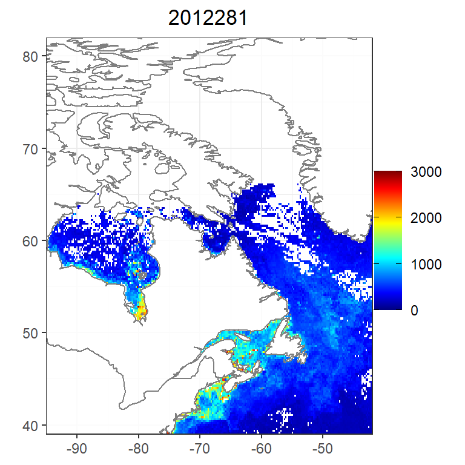

##### Daily PP, and % difference from 8day average

Note that the %error - chla correlation coefficient here was calculated using the 8day chla.

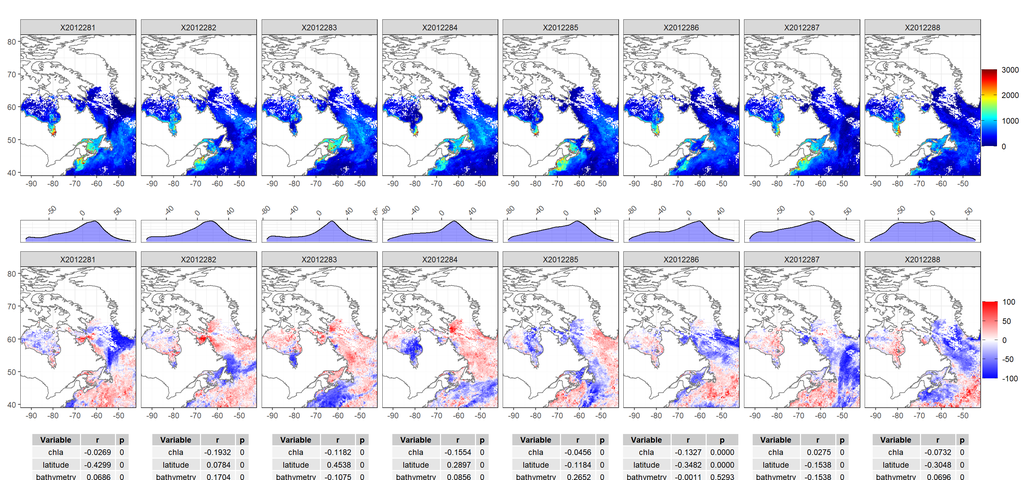

##### Summary

Density plot of PP generated in the Northwest Atlantic using monthly, 8day, or daily input.

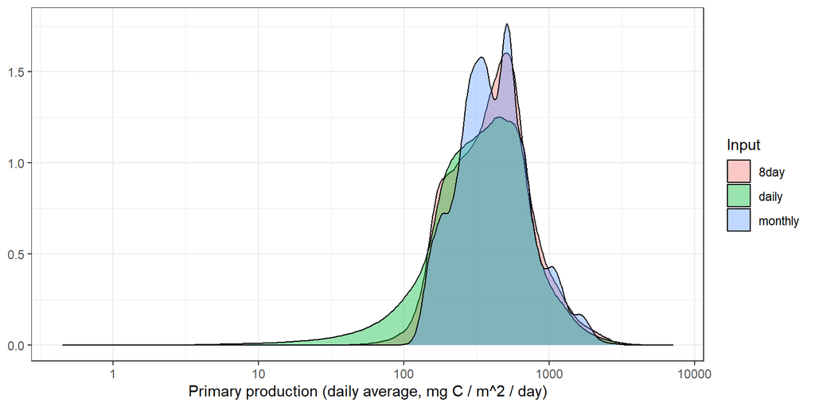

### 201501

#### Monthly average daily PP

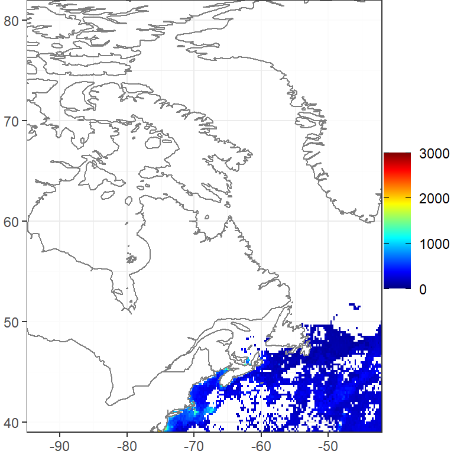

##### 8day average daily PP, and % difference from monthly average

Note that the %error - chla correlation coefficient here was calculated using the monthly chla.

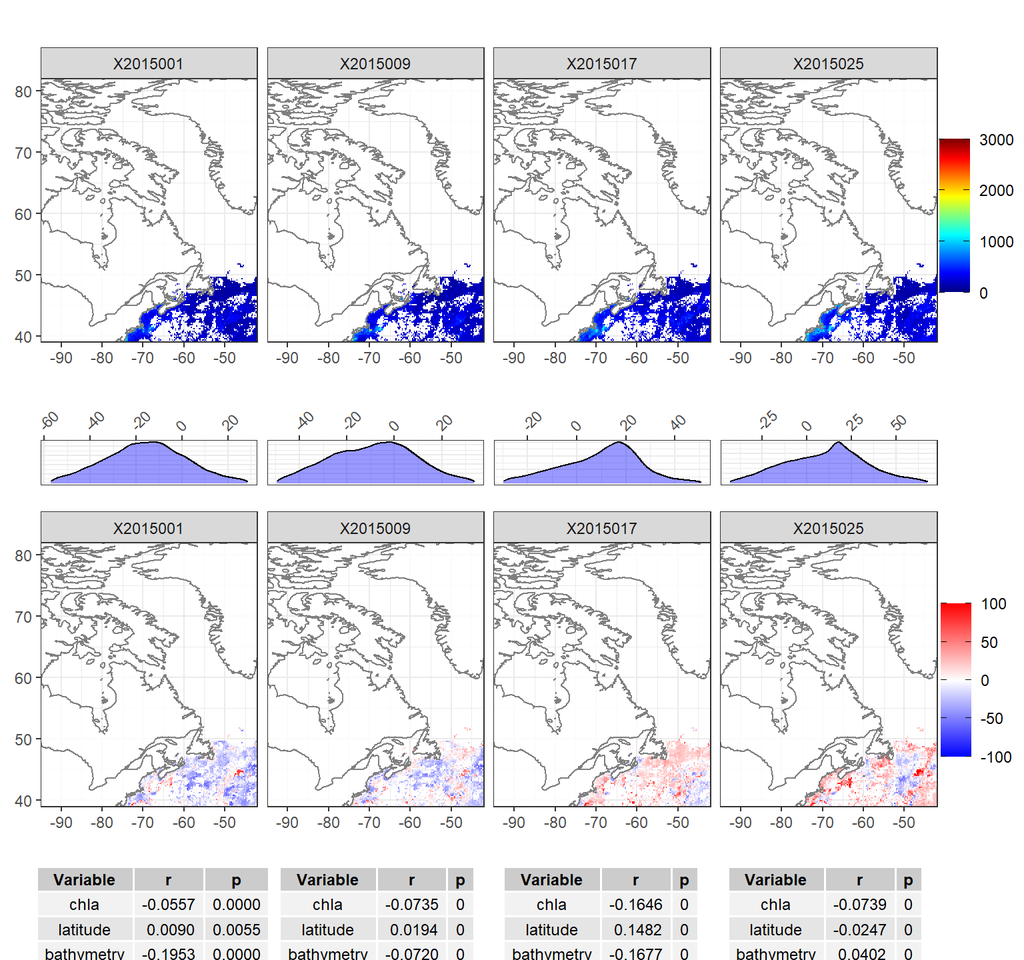

#### 8day average daily PP

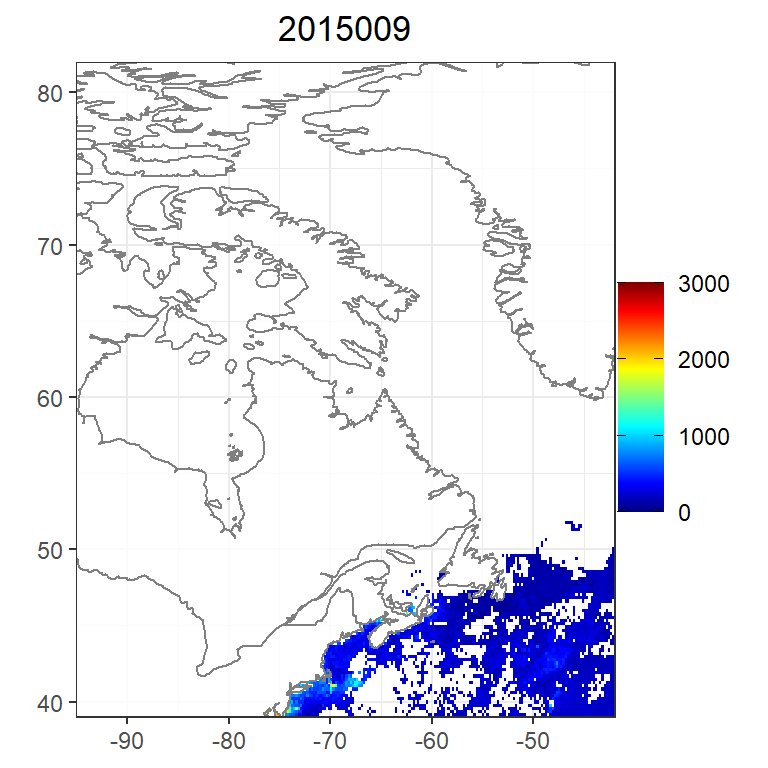

##### Daily PP, and % difference from 8day average

Note that the %error - chla correlation coefficient here was calculated using the 8day chla.

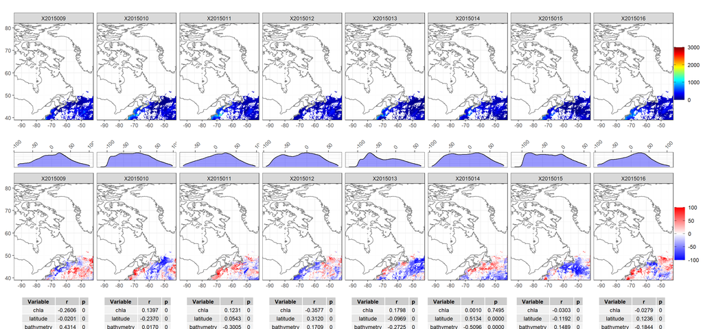

##### Summary

Density plot of PP generated in the Northwest Atlantic using monthly, 8day, or daily input.

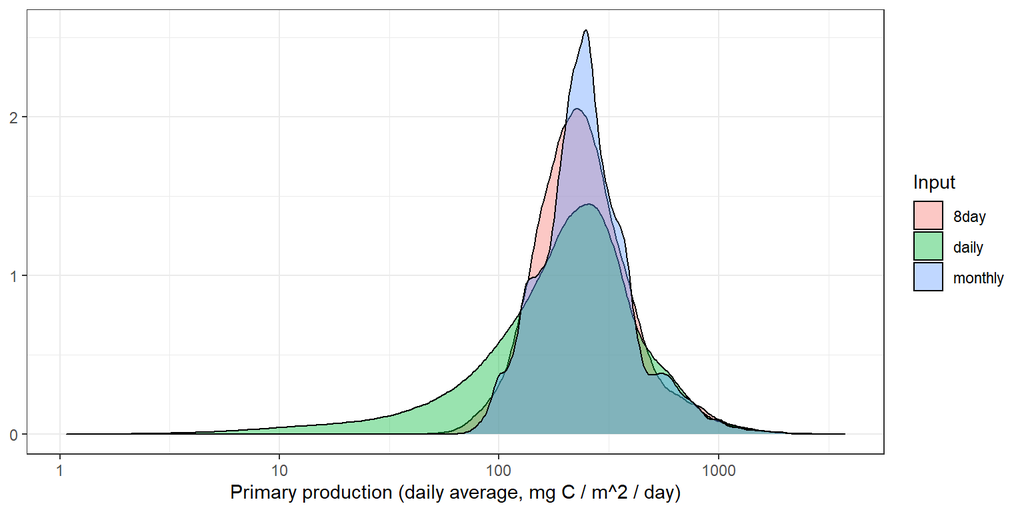

### 201704

#### Monthly average daily PP

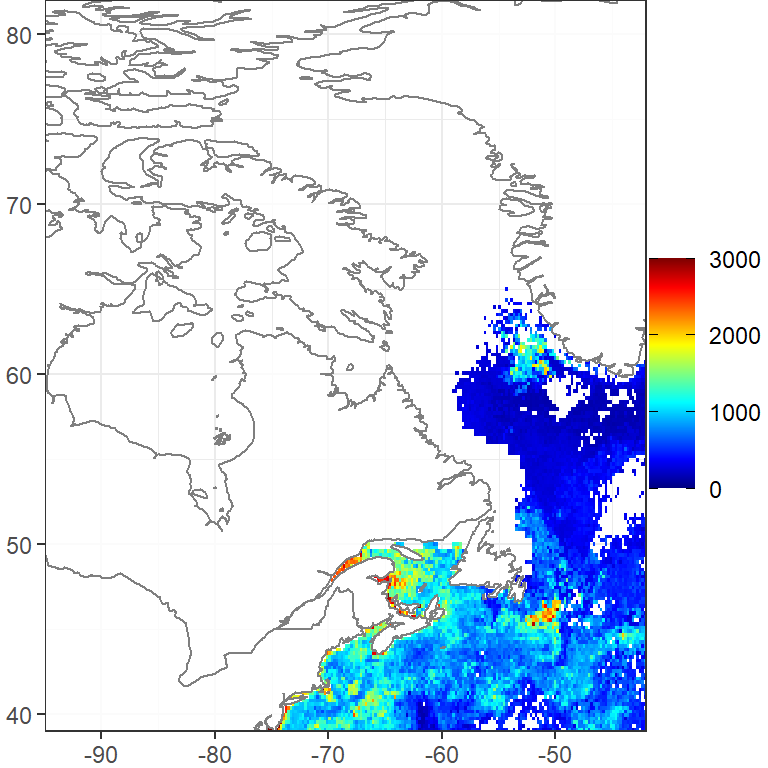

##### 8day average daily PP, and % difference from monthly average

Note that the %error - chla correlation coefficient here was calculated using the monthly chla.

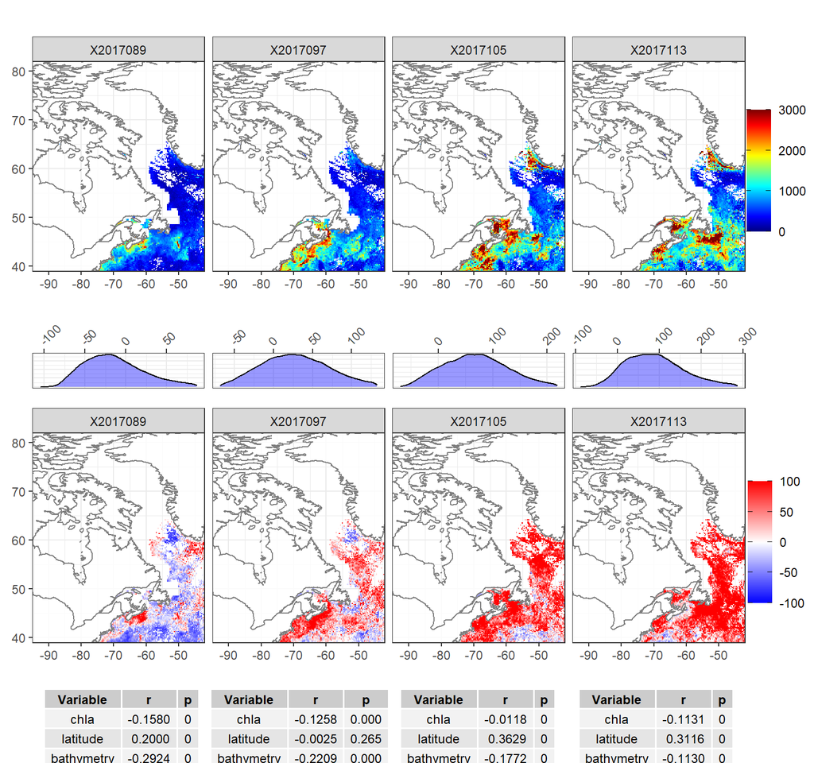

#### 8day average daily PP

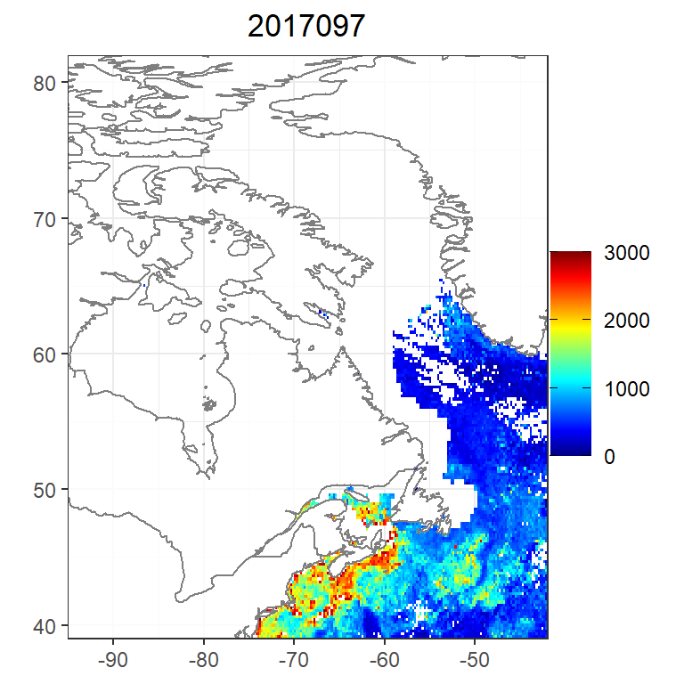

##### Daily PP, and % difference from 8day average

Note that the %error - chla correlation coefficient here was calculated using the 8day chla.

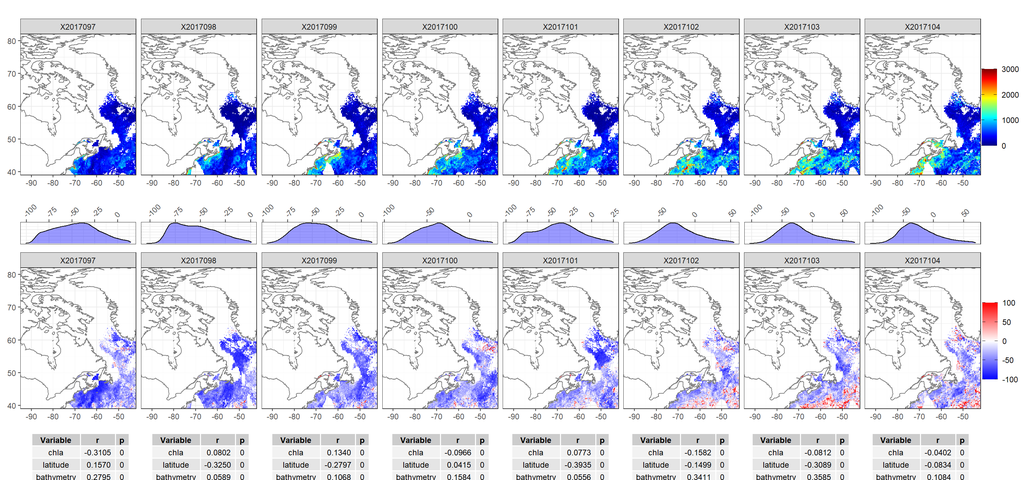

##### Summary

Density plot of PP generated in the Northwest Atlantic using monthly, 8day, or daily input.

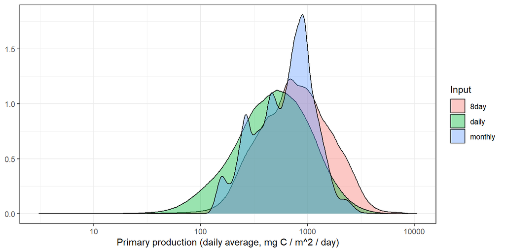

### 201807

#### Monthly average daily PP

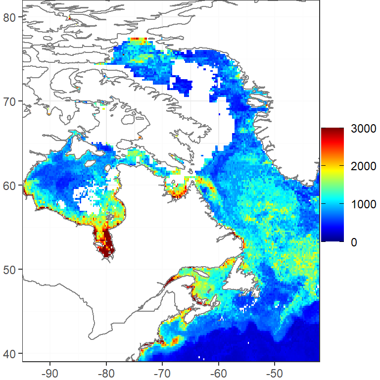

##### 8day average daily PP, and % difference from monthly average

Note that the %error - chla correlation coefficient here was calculated using the monthly chla.

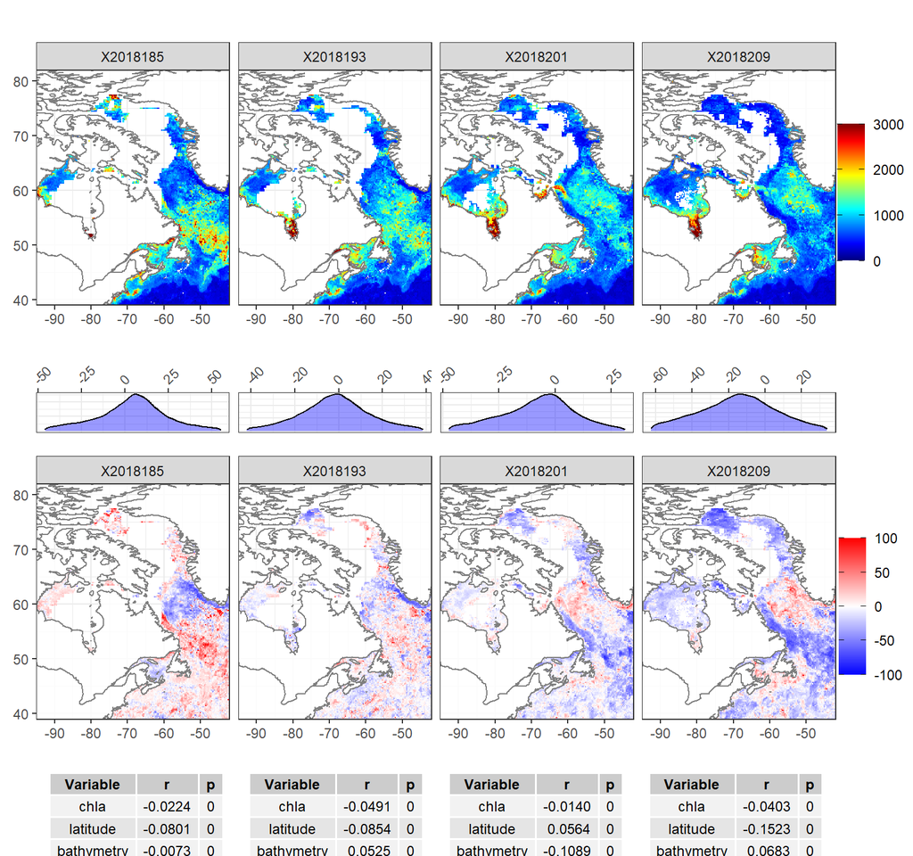

#### 8day average daily PP

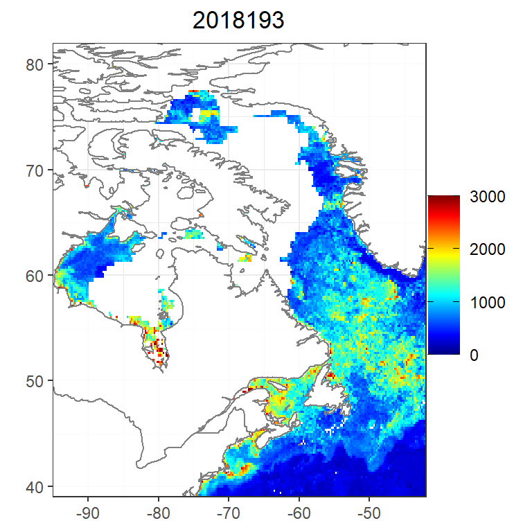

##### Daily PP, and % difference from 8day average

Note that the %error - chla correlation coefficient here was calculated using the 8day chla.

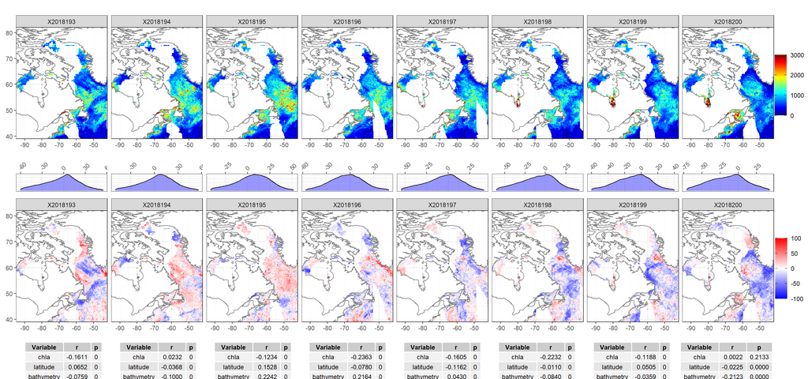

##### Summary

Density plot of PP generated in the Northwest Atlantic using monthly, 8day, or daily input.

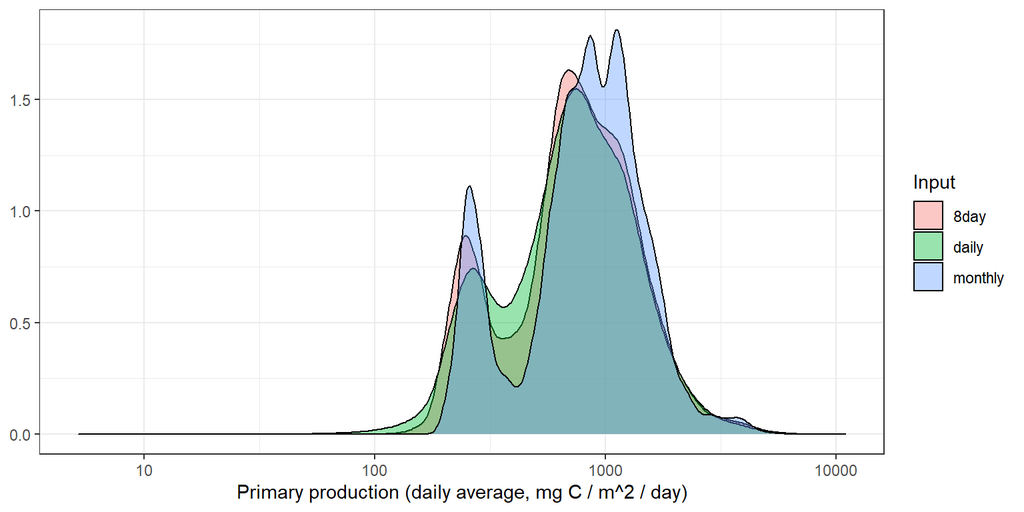